# PROSeq Gene Expression Analysis and Comparison: GSK591 Timecourse in A549

### **Output Directory Structure**

During execution, the script creates the following directories under `params$output_dir` to organize the results:

1. **tables/**: Contains CSV files with processed data and cluster assignments.
2. **plots/**: Stores all visualizations such as volcano plots, scatter plots, and heatmaps.
3. **geneOverlap/**: Contains GeneOverlap result tables and heatmaps.
4. **ClusterProfiler/**: Stores gene ontology (GO) and pathway enrichment results and plots.
5. **GSEA/**: (If implemented) For Gene Set Enrichment Analysis output.

#Setup *Load libraries and create output directories*

*Load and prepare data*

#Load and prepare data

```
## [1] "Unfiltered genome size (number of genes tested in DESeq2): 87607"
```

- Plot p-value histograms *

#p-value histograms

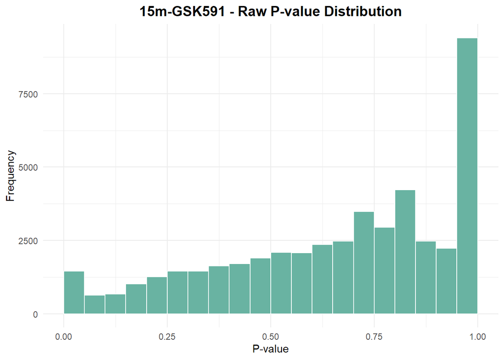

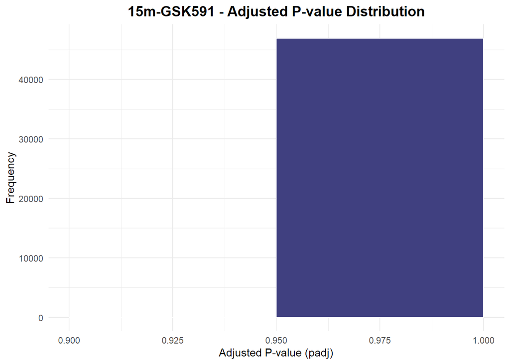

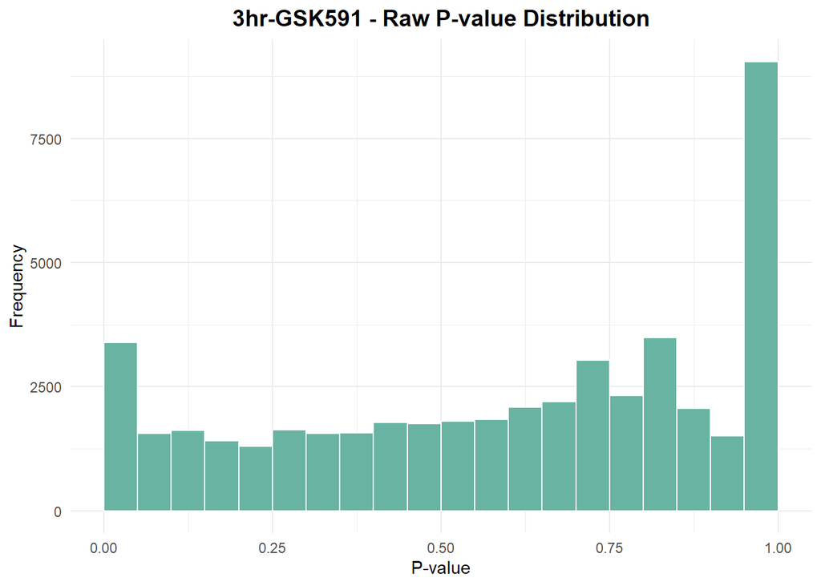

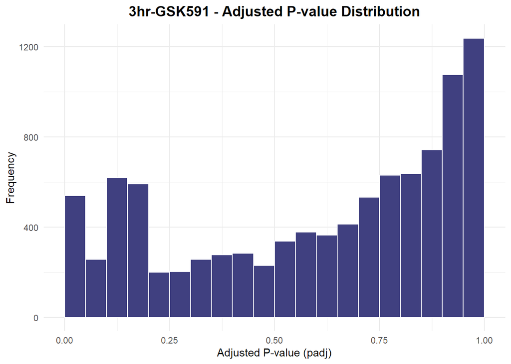

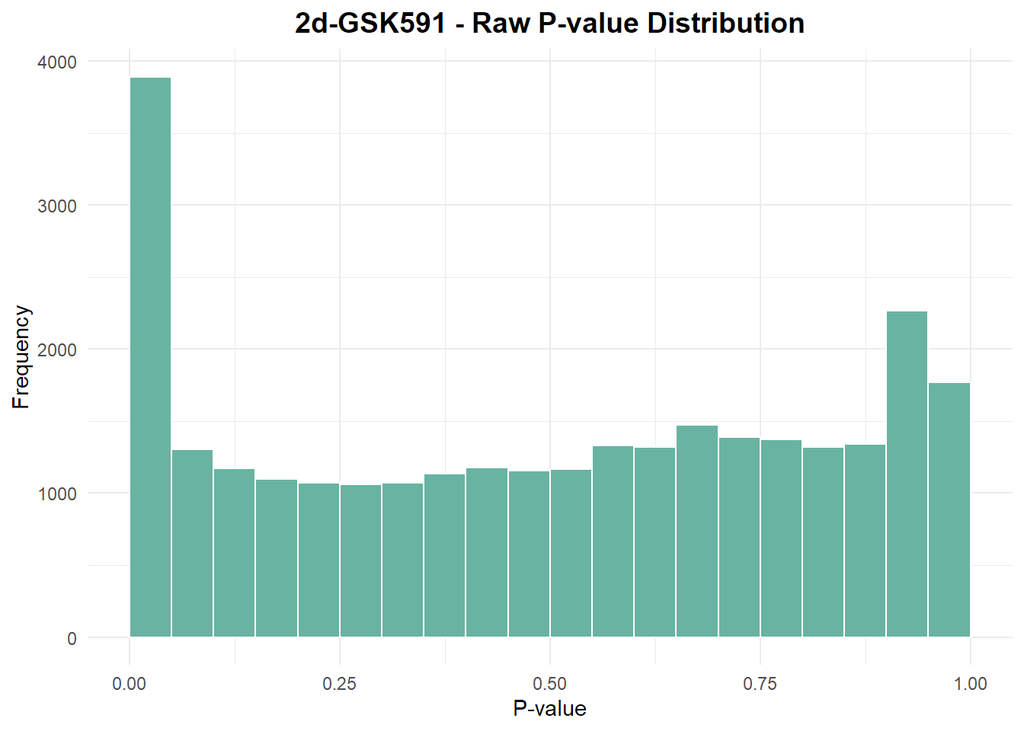

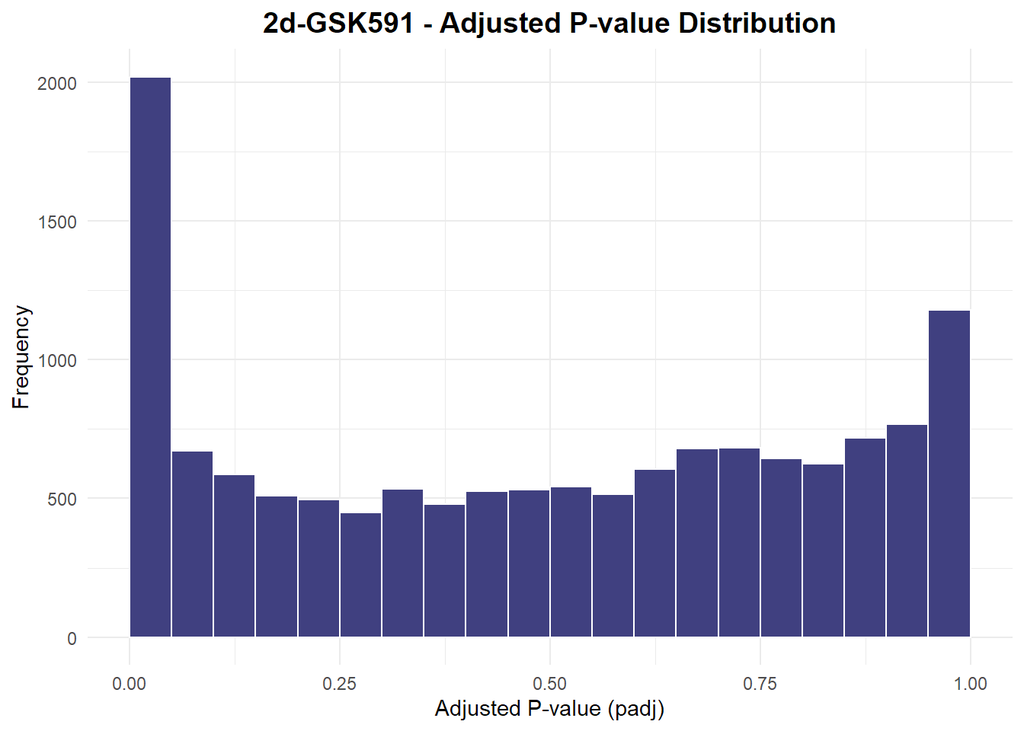

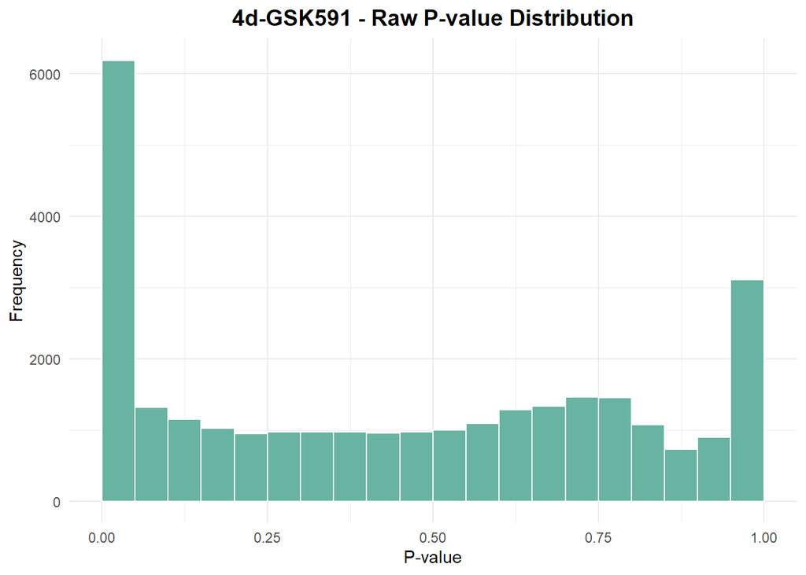

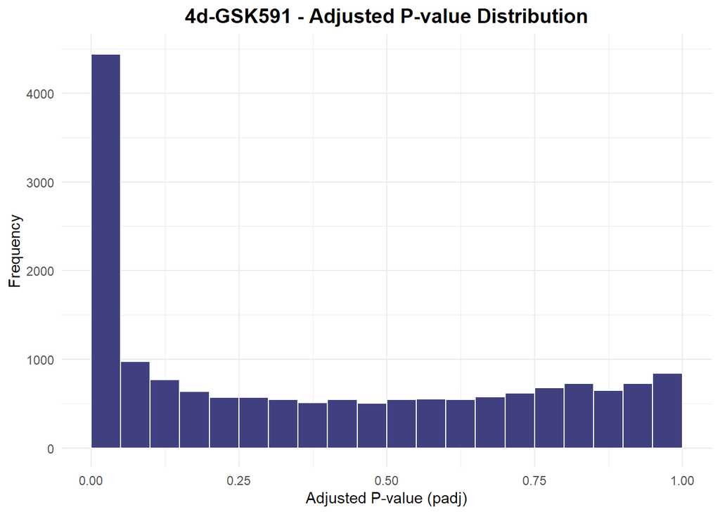

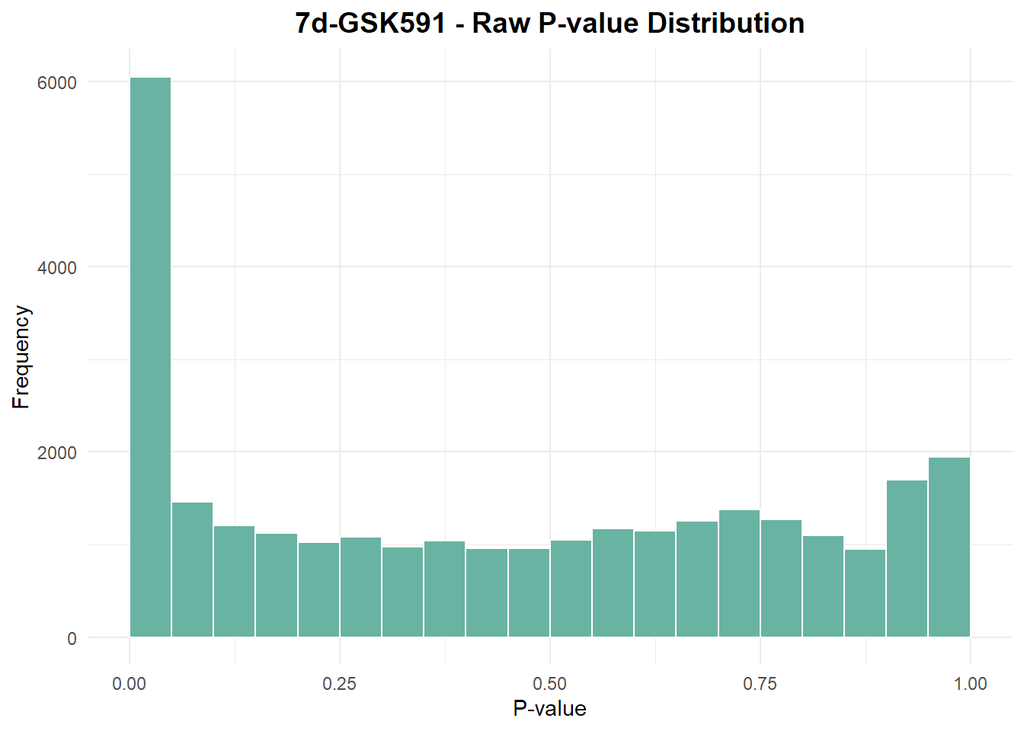

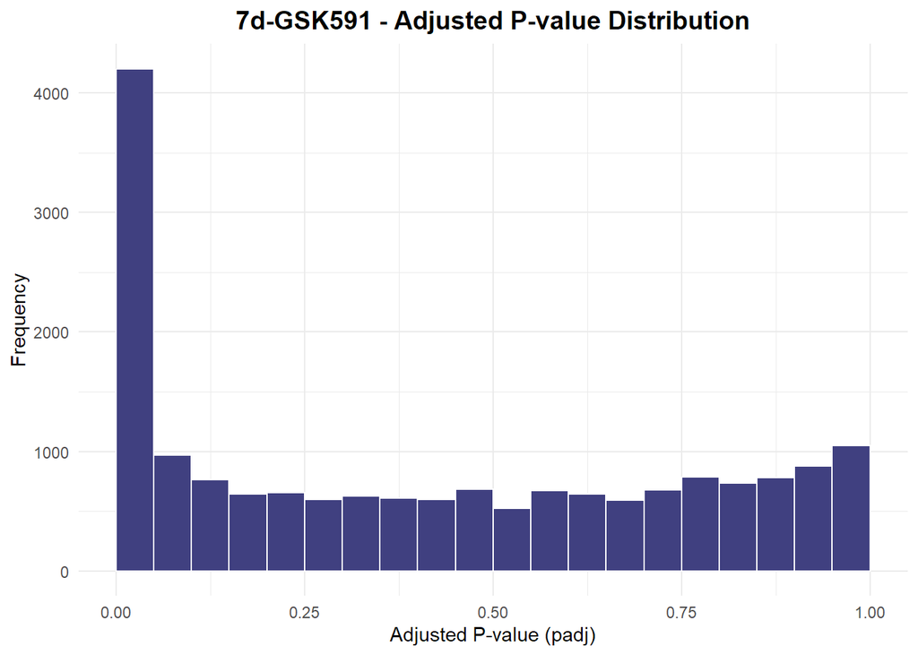

#Volcano Plots *Plot Volcanos*

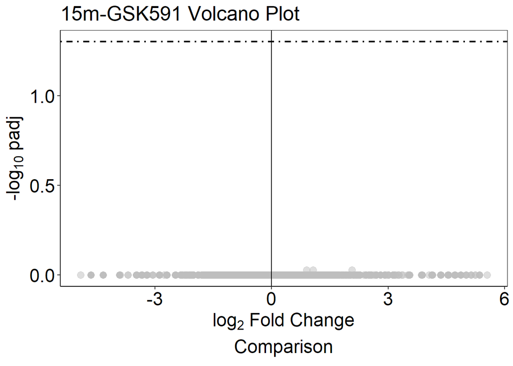

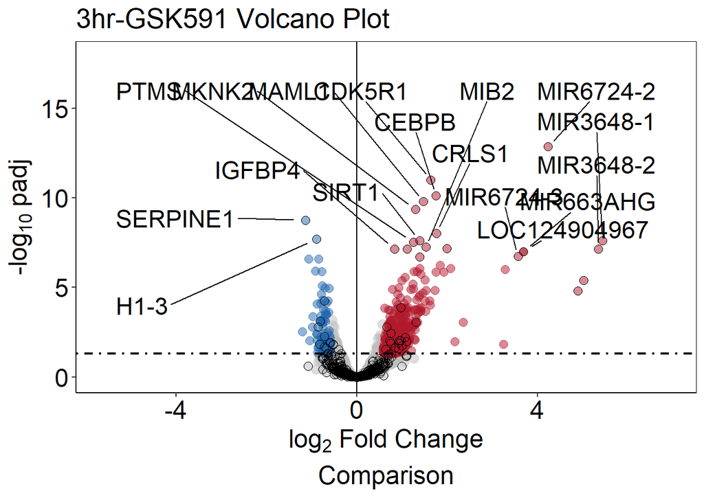

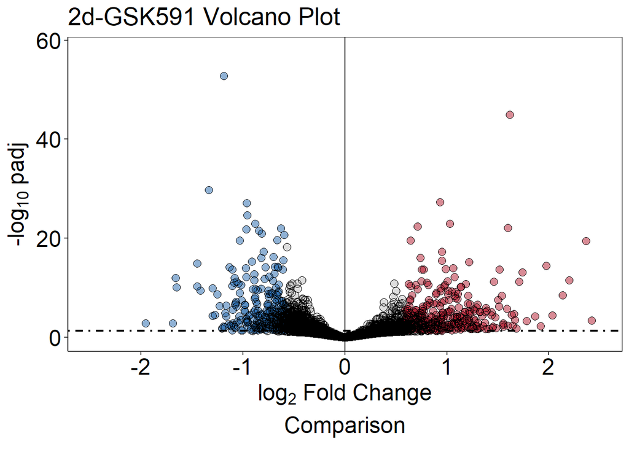

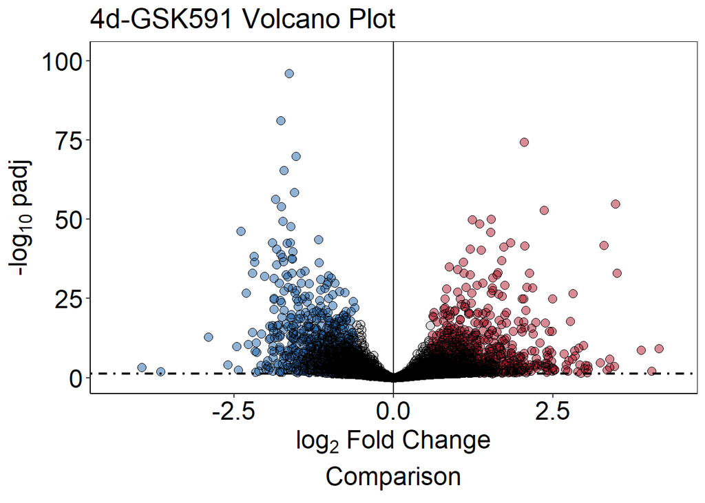

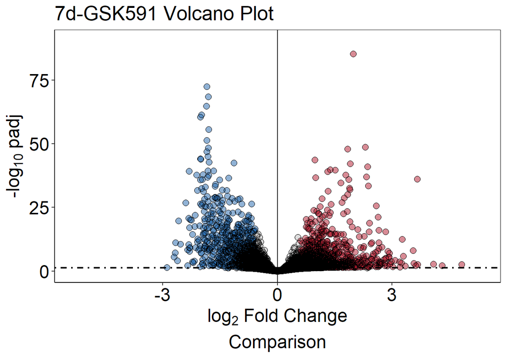

#GeneOverlap *Perform GeneOverlap analysis and plot heatmaps*

```
## [1] "Gene list sizes:"
## 15m-GSK591 3hr-GSK591  2d-GSK591  4d-GSK591  7d-GSK591
##          0        535       2020       4443       4203
## Calculated dynamic genome size: 87607
```

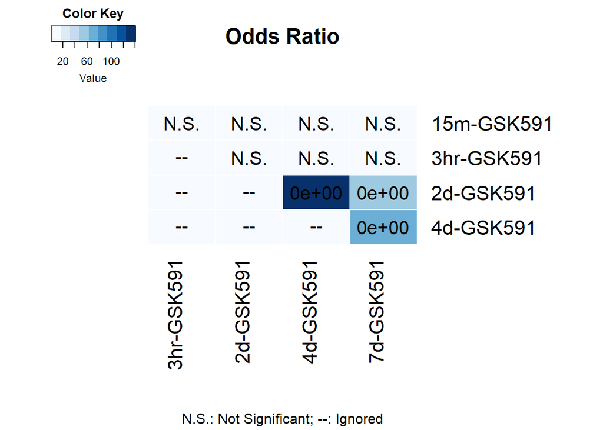

[output not shown]

[output cut: 65 more lines]

[output not shown]

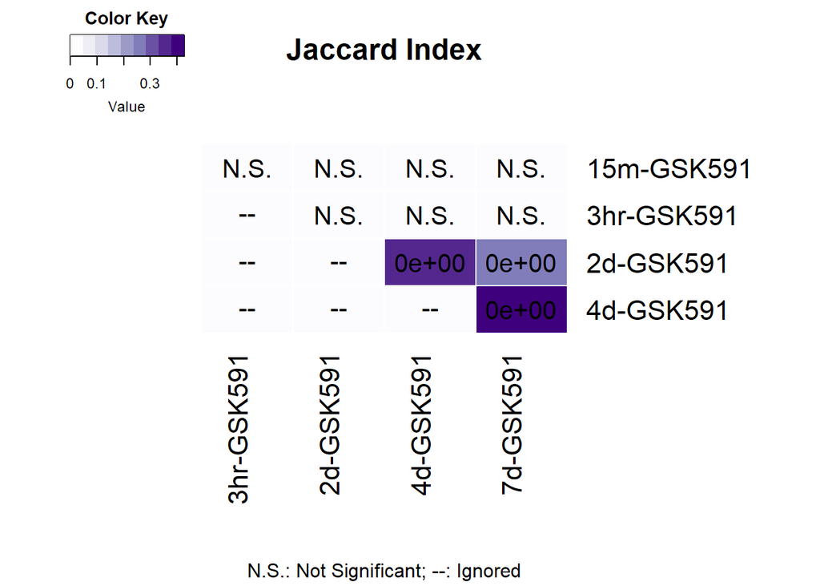

[output not shown]

[output cut: 171 more lines]

[output not shown]

#TPM Heatmap

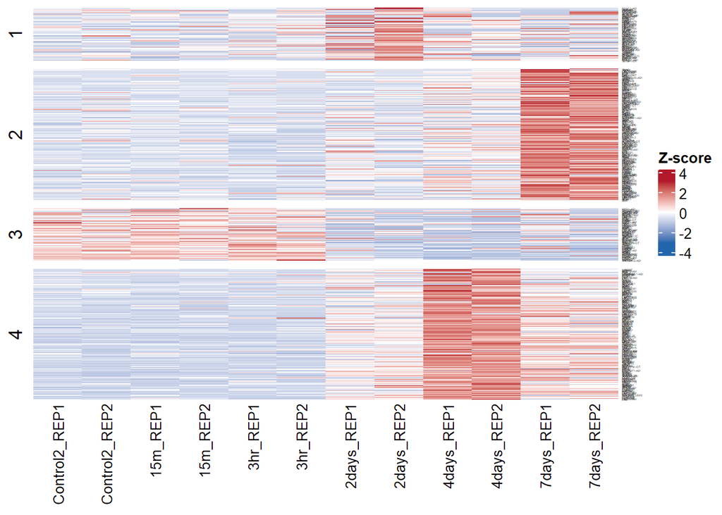